# Brief intro to Spatial Data in R

[EFB 654: R and Reproducible Research](https://eligurarie.github.io/EFB654/)

Elie Gurarie

2026-04-20

# Key packages

### Vector data

- **`sf`** — *simple features*
  - points, lines, polygons
  - all functions prefixed `st_`
  - reads (GIS) shape files

### Raster data

- **`terra`** — modern raster (and vector)
  - successor to `raster`
  - faster, actively developed
- **`raster`** — older, still widely used, still has features not available in terra

### Visualization

- **`mapview`** — quick, interactive leaflet maps (one-liner)
- **`ggplot2::geom_sf()`** — static maps in the grammar of graphics
- **`maps`** — base R country/state outlines

> Older vector packages (`sp`, `rgdal`, `rgeos`) are **retired** as of 2023, but will come up often … especially as dependencies in other packages.

# Simple Features (`sf`)

## What is a “simple feature”?

A **simple feature** is a “standard” for 2D vector geometry. Every `sf` object is a **data frame with a geometry column**:

- **POINT** — e.g., a GPS fix, a nest, a city
- **LINESTRING** — a track, a river, a road
- **POLYGON** — a home range, a lake, a park
- … plus `MULTI*` versions

Each row is one feature; the `geometry` column holds its coordinates. Every `sf` function starts with `st_` (*spatial / temporal*).

*source: r-spatial.github.io/sf*

## Data frame to `sf`

Four Syracuse landmarks:

```r
syr <- data.frame(
  name = c("Great Law of Peace Center", "SUNY-ESF", "Barry Park", "Onondaga Lake"),
  lon  = c(-76.1967, -76.1356, -76.1149, -76.2175),
  lat  = c( 43.0936,  43.0354, 43.0267,  43.0967)
)
syr
```

```
##                        name      lon     lat
## 1 Great Law of Peace Center -76.1967 43.0936
## 2                  SUNY-ESF -76.1356 43.0354
## 3                Barry Park -76.1149 43.0267
## 4             Onondaga Lake -76.2175 43.0967
```

The key function is `st_as_sf`:

```r
require(sf)
syr_sf <- st_as_sf(syr, coords = c("lon", "lat"), crs = 4326)
```

`crs = 4326` → **WGS84 lon/lat** (default for GPS data). `coords =` specifies the column names with lon-lat (NOT lat-lon!).

```r
syr_sf
```

```
## Simple feature collection with 4 features and 1 field
## Geometry type: POINT
## Dimension:     XY
## Bounding box:  xmin: -76.2175 ymin: 43.0267 xmax: -76.1149 ymax: 43.0967
## Geodetic CRS:  WGS 84
##                        name                 geometry
## 1 Great Law of Peace Center POINT (-76.1967 43.0936)
## 2                  SUNY-ESF POINT (-76.1356 43.0354)
## 3                Barry Park POINT (-76.1149 43.0267)
## 4             Onondaga Lake POINT (-76.2175 43.0967)
```

Note the **`geometry`** list-column.

## `st_geometry` and `st_coordinates`

**`st_geometry()`** extracts just the geometry column (a list of POINTs, a.k.a. an `sfc`):

```r
st_geometry(syr_sf)
```

[output not shown]

**`st_coordinates()`** returns a plain numeric matrix of coordinates, handy for base R or for passing to non-spatial functions:

```r
st_coordinates(syr_sf)
```

```
##             X       Y
## [1,] -76.1967 43.0936
## [2,] -76.1356 43.0354
## [3,] -76.1149 43.0267
## [4,] -76.2175 43.0967
```

Compare: `st_drop_geometry()` goes the other way — returns the attribute table only.

## Base plot

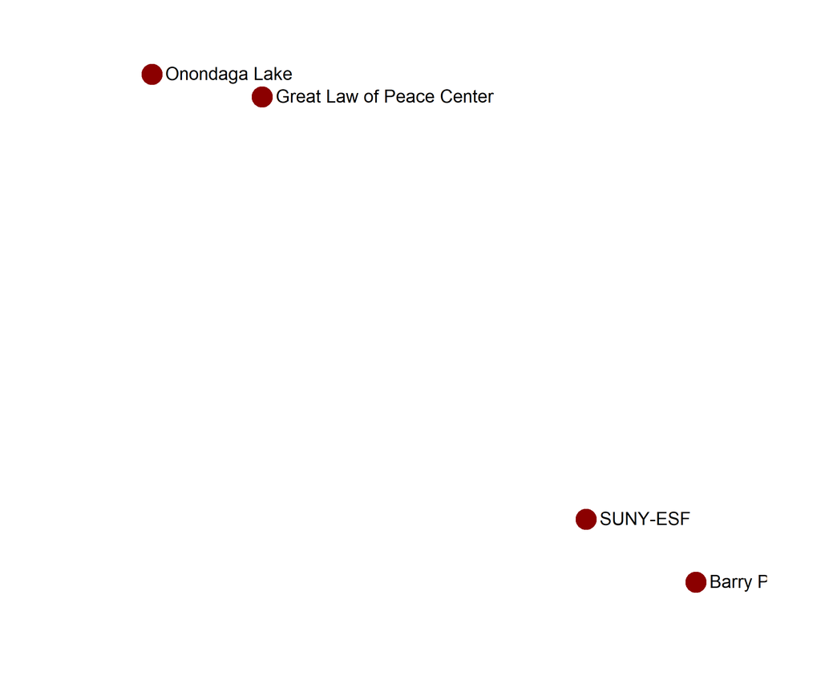

```r
plot(st_geometry(syr_sf), pch = 19, col = "darkred", cex = 2)
text(st_coordinates(syr_sf), labels = syr_sf$name, pos = 4, cex = 0.8)
```

## `ggplot` (`geom_sf`)

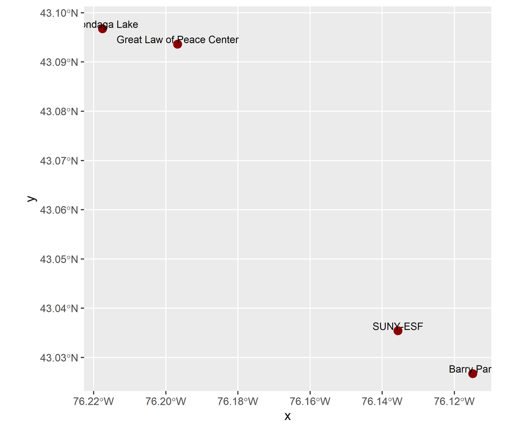

```r
require(ggplot2)
ggplot(syr_sf) +
  geom_sf(color = "darkred", size = 3) +
  geom_sf_text(aes(label = name), nudge_y = 0.001, size = 3)
```

`geom_sf()` auto-handles the CRS and aspect ratio.

## `mapview`

One line, fully interactive (pan, zoom, basemap, popups):

```r
require(mapview)
mapview(syr_sf, label = "name", col.regions = "darkred", cex = 6)
```

[interactive chart not shown]

Works inline in any RMarkdown.

# Rasters

## What is a raster?

A **raster** is a regular grid of cells, each holding a value.

- **Continuous** — elevation, temperature, NDVI
- **Categorical** — land cover, soil type, habitat class

Defined by:

- **extent** (xmin, xmax, ymin, ymax)
- **resolution** (cell size)
- **CRS** (projection)
- **values** (one or more layers / bands)

### `terra` vs. `raster`

- `terra` is the modern replacement — faster, C++ backend, unified vector + raster
- Core class is `SpatRaster` (vs. `RasterLayer` in `raster`)
- Most function names carry over: `rast()`, `crop()`, `extract()`, `project()`, `plot()`

## Loading and plotting

```r
require(terra)
syr_nlcd <- rast("syr_nlcd.tif")
syr_nlcd
```

```
## class       : SpatRaster
## size        : 802, 548, 1  (nrow, ncol, nlyr)
## resolution  : 30, 30  (x, y)
## extent      : 1588575, 1605015, 2383635, 2407695  (xmin, xmax, ymin, ymax)
## coord. ref. : NAD83 / Conus Albers (EPSG:5070)
## source      : syr_nlcd.tif
## color table : 1
## categories  : NLCD Land Cover Class, Histogram, Red, Green, Blue, Opacity
## name        :         NLCD Land Cover Class
## min value   :                    Open Water
## max value   : Emergent Herbaceuous Wetlands
```

Note the CRS: **Albers Equal Area Conic / NAD83** — the native NLCD projection (units: meters), *not* lon/lat.

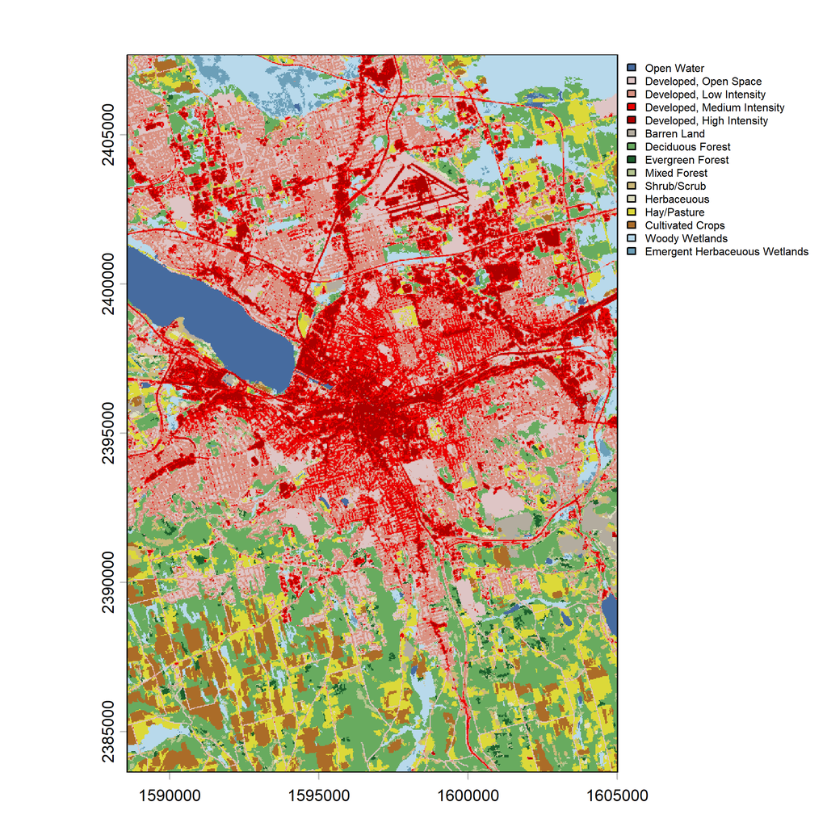

```r
plot(syr_nlcd, plg = list(cex = 0.6))
```

> **National Land Cover Database** — 30 m categorical land cover for the U.S., updated every 2–3 years.

## Interactive view with `mapview`

```r
require(mapview)
mapview(syr_nlcd)
```

[interactive chart not shown]

`mapview` reprojects on the fly to web-mercator (EPSG:3857) and overlays on an interactive basemap — good for sanity-checking extent and alignment.

## Extracting values: align CRS first

`terra::extract()` pulls raster values at vector locations — but **the CRS must match**. Our points are in **WGS84 lon/lat** (EPSG:4326); the raster is in **Albers NAD83**.

```r
st_crs(syr_sf)
```

```
## Coordinate Reference System:
##   User input: EPSG:4326
##   wkt:
## GEOGCRS["WGS 84",
##     ENSEMBLE["World Geodetic System 1984 ensemble",
##         MEMBER["World Geodetic System 1984 (Transit)"],
##         MEMBER["World Geodetic System 1984 (G730)"],
##         MEMBER["World Geodetic System 1984 (G873)"],
##         MEMBER["World Geodetic System 1984 (G1150)"],
##         MEMBER["World Geodetic System 1984 (G1674)"],
##         MEMBER["World Geodetic System 1984 (G1762)"],
##         MEMBER["World Geodetic System 1984 (G2139)"],
##         MEMBER["World Geodetic System 1984 (G2296)"],
##         ELLIPSOID["WGS 84",6378137,298.257223563,
##             LENGTHUNIT["metre",1]],
##         ENSEMBLEACCURACY[2.0]],
##     PRIMEM["Greenwich",0,
##         ANGLEUNIT["degree",0.0174532925199433]],
##     CS[ellipsoidal,2],
##         AXIS["geodetic latitude (Lat)",north,
##             ORDER[1],
##             ANGLEUNIT["degree",0.0174532925199433]],
##         AXIS["geodetic longitude (Lon)",east,
##             ORDER[2],
##             ANGLEUNIT["degree",0.0174532925199433]],
##     USAGE[
##         SCOPE["Horizontal component of 3D system."],
##         AREA["World."],
##         BBOX[-90,-180,90,180]],
##     ID["EPSG",4326]]
```

```r
crs(syr_nlcd, describe = TRUE)$name
```

```
## [1] "NAD83 / Conus Albers"
```

Transform the points into the raster’s CRS:

```r
syr_sf <- st_transform(syr_sf, crs(syr_nlcd))
```

Coordinates are now in meters (Albers), matching the raster.

Extract land cover at each point:

```r
syr_sf$nlcd <- extract(syr_nlcd, syr_sf)[,2]
syr_sf
```

```
## Simple feature collection with 4 features and 2 fields
## Geometry type: POINT
## Dimension:     XY
## Bounding box:  xmin: 1590369 ymin: 2393706 xmax: 1600121 ymax: 2399643
## Projected CRS: NAD83 / Conus Albers
##                        name                geometry                      nlcd
## 1 Great Law of Peace Center POINT (1592088 2399643)  Developed, Low Intensity
## 2                  SUNY-ESF POINT (1598278 2394308) Developed, High Intensity
## 3                Barry Park POINT (1600121 2393706)          Deciduous Forest
## 4             Onondaga Lake POINT (1590369 2399633)                Open Water
```

### Overlay on the raster

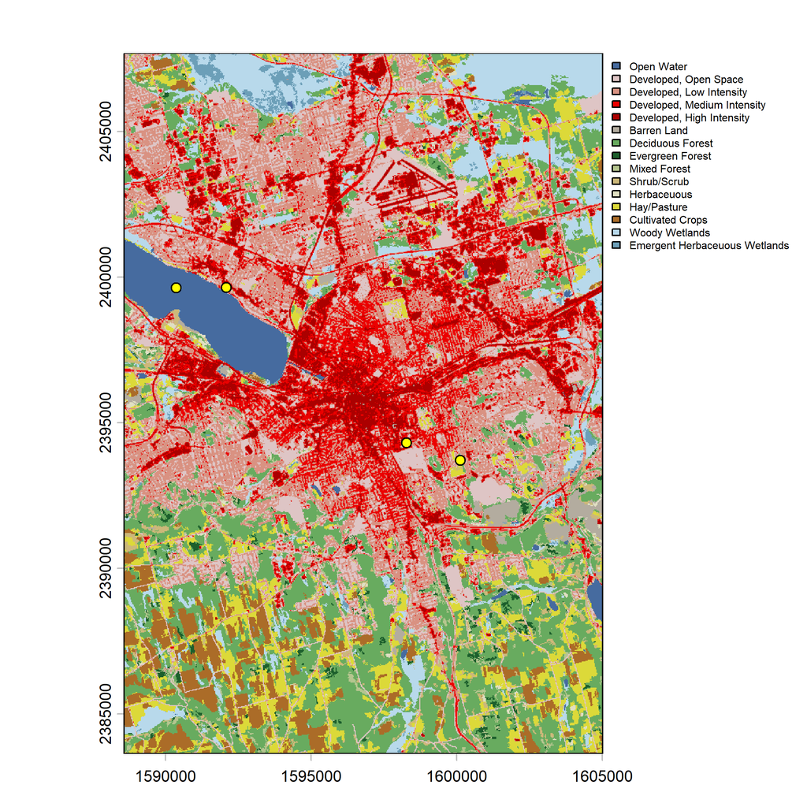

```r
plot(syr_nlcd, plg = list(cex = 0.6))
plot(st_geometry(syr_sf), add = TRUE, pch = 21, bg = "yellow")
```

# Some spatial take-aways

- Easy and powerful and fast.
- When you combine vector data with raster data … ALWAYS transform the *vector*, never the *raster*.